# Gagan Makhiza

## Reproducible research Course Project 1

## 1. Loading and preprocessing the data

1. Load the data (i.e. read.csv()).

```r
act <- read.csv("activity.csv")
```

## What is mean total number of steps taken per day?

1. Calculate the total number of steps taken per day.

```r
library(dplyr)
actSum <- act %>% group_by(date) %>% summarise(stepSum = sum(steps))
```

2. Make a histogram of the total number of steps taken each day.

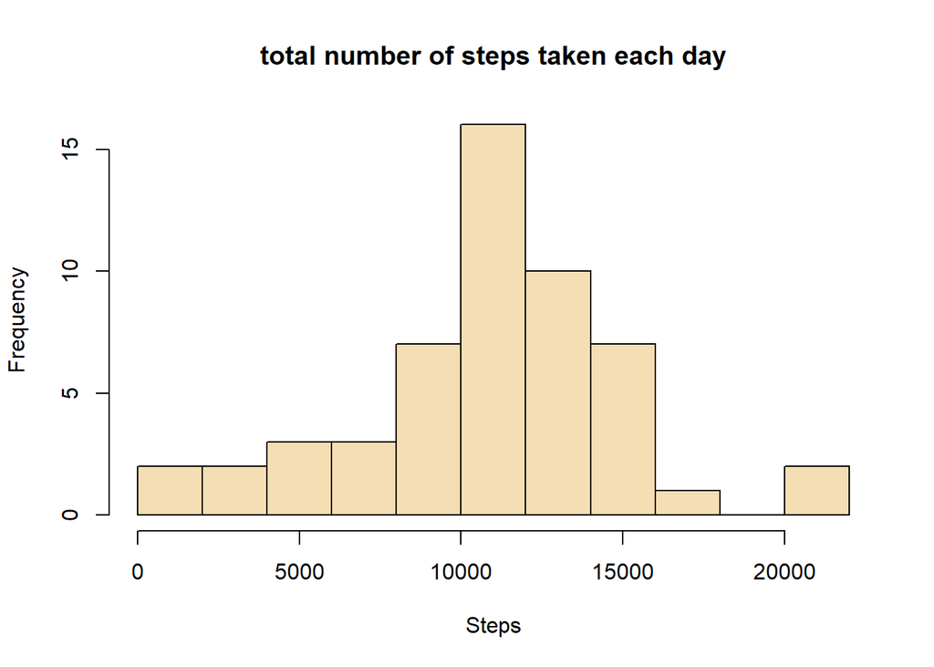

```r
hist(actSum$stepSum, breaks = 10, main = "total number of steps taken each day", xlab = "Steps", col = "wheat")
```

```r
actMean <- act %>% group_by(date) %>% summarise(stepSum = mean(steps))
actMedian <- act %>% group_by(date) %>% summarise(stepSum = median(steps))
```

## What is the average daily activity pattern?

[figure not shown]

```r
actInt <- act %>% group_by(interval) %>% summarise(stepInt = sum(steps, na.rm = T))
plot(actInt$interval, actInt$stepInt, type = "l", main = "average no. of steps taken", ylab = "averaged across all day", xlab = "5-min interval")
```

2. Which 5-minute interval, on average across all the days in the dataset, contains the maximum number of steps?

```r
maxint <- actInt[actInt$stepInt == max(actInt), 1]
maxint
```

| interval |
| --- |
| 835 |

## Imputing missing values

1. Calculate and report the total number of missing values in the dataset.

```r
sum(is.na(act))
```

```
## [1] 2304
```

2. Devise a strategy for filling in all of the missing values in the dataset. The strategy does not need to be sophisticated. For example, you could use the mean/median for that day, or the mean for that 5-minute interval, etc.

Strategy taken is to substitute each NA with a fixed value. I set the fixed value equivalent to the overall mean of the variable act$steps.

3. Create a new dataset that is equal to the original dataset but with the missing data filled in.

```r
act2 <- act
act2$steps[is.na(act2$steps)] <- mean(na.omit(act$steps))
sum(is.na(act2))
```

```
## [1] 0
```

```r
## Report

sum_mean_median_day <- group_by(act2, date) %>%
     summarise(sum_steps = sum(steps),
               mean_steps = mean(steps),
               median_steps = median(steps))
 sum_mean_median_day
```

| date | sum_steps | mean_steps | median_steps |
| --- | --- | --- | --- |
| 2012-10-01 | 10766.19 | 37.3825996 | 37.3826 |
| 2012-10-02 | 126.00 | 0.4375000 | 0.0000 |
| 2012-10-03 | 11352.00 | 39.4166667 | 0.0000 |
| 2012-10-04 | 12116.00 | 42.0694444 | 0.0000 |
| 2012-10-05 | 13294.00 | 46.1597222 | 0.0000 |
| 2012-10-06 | 15420.00 | 53.5416667 | 0.0000 |
| 2012-10-07 | 11015.00 | 38.2465278 | 0.0000 |
| 2012-10-08 | 10766.19 | 37.3825996 | 37.3826 |
| 2012-10-09 | 12811.00 | 44.4826389 | 0.0000 |
| 2012-10-10 | 9900.00 | 34.3750000 | 0.0000 |

[output cut: 51 more lines]

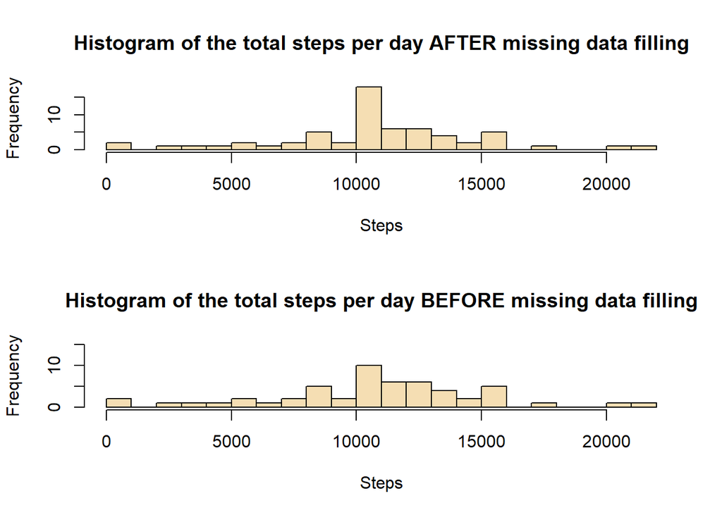

```r
 ## Histogram
 par(mfcol = c(2,1))
 hist(sum_mean_median_day$sum_steps, main = "Histogram of the total steps per day AFTER missing data filling", xlab = "Steps", breaks = 16, col = "wheat")
 hist(actSum$stepSum, main = "Histogram of the total steps per day BEFORE missing data filling", xlab = "Steps",   breaks = 16, col = "wheat", ylim = c(0,15))
```

## Are there differences in activity patterns between weekdays and weekends?

1. Create a new factor variable in the dataset with two levels - “weekday” and “weekend” indicating whether a given date is a weekday or weekend day.

```r
act2$date = as.Date(act2$date, "%Y-%m-%d")
state <- ifelse(weekdays(act2$date) %in% c("Saturday", "Sunday"), "weekend", "weekday")
state <- as.factor(state)
act2$state <- state
```

2. Make a panel plot containing a time series plot of the 5-minute interval (x-axis) and the average number of steps taken, averaged across all weekday days or weekend days (y-axis). See the README file in the GitHub repository to see an example of what this plot should look like using simulated data.

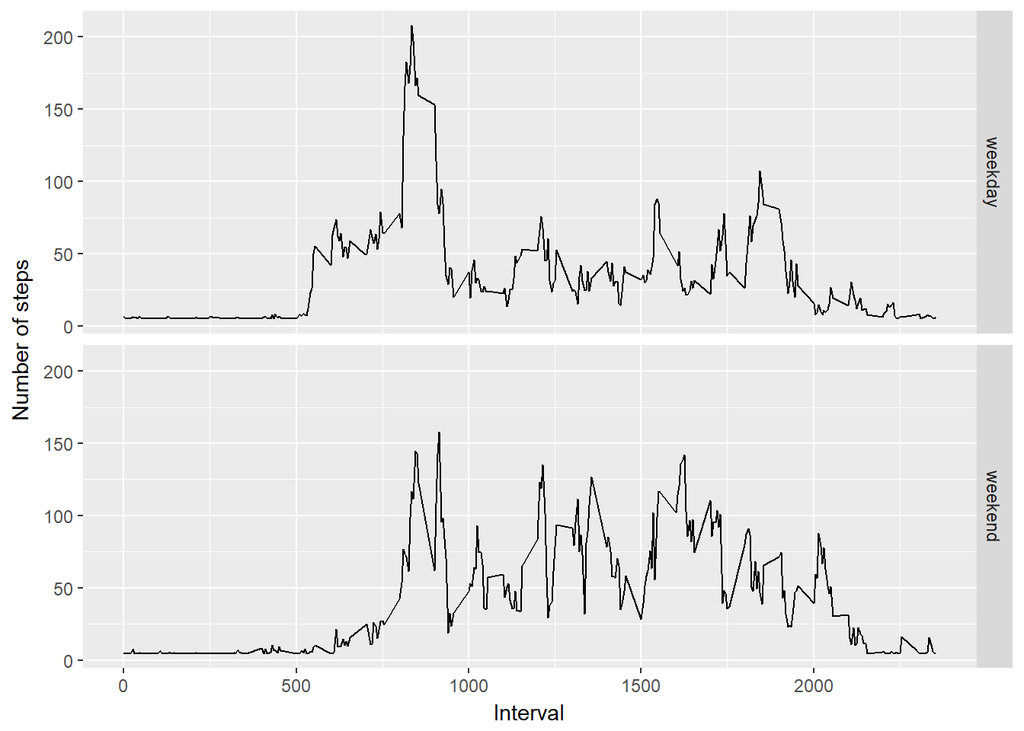

```r
library(ggplot2)
average_steps_state <- group_by(act2, state, interval) %>% summarise(average_steps = mean(steps))

ggplot(average_steps_state, aes(x = interval, y = average_steps)) +
    geom_line() +
    facet_grid(state ~ .) +
    labs(x = "Interval") +
    labs(y = "Number of steps")
```